# Data Science for Public Policy

Stretch Exercise - Assignment 7

Author

Olivia Gomez

## Stretch Exercise - Assignment 7

I am using data from the National Health Interview Survey. This survey is conducted each year to capture statistical information on the amount, distribution, and effects of illness and disability in the United States. The units of measurement are individual adults. I will be utilizing a supervised machine learning model to predict health status (a measure of one’s self-reported health on a scale of 1 to 5) based on several different factors.

1. Set Up

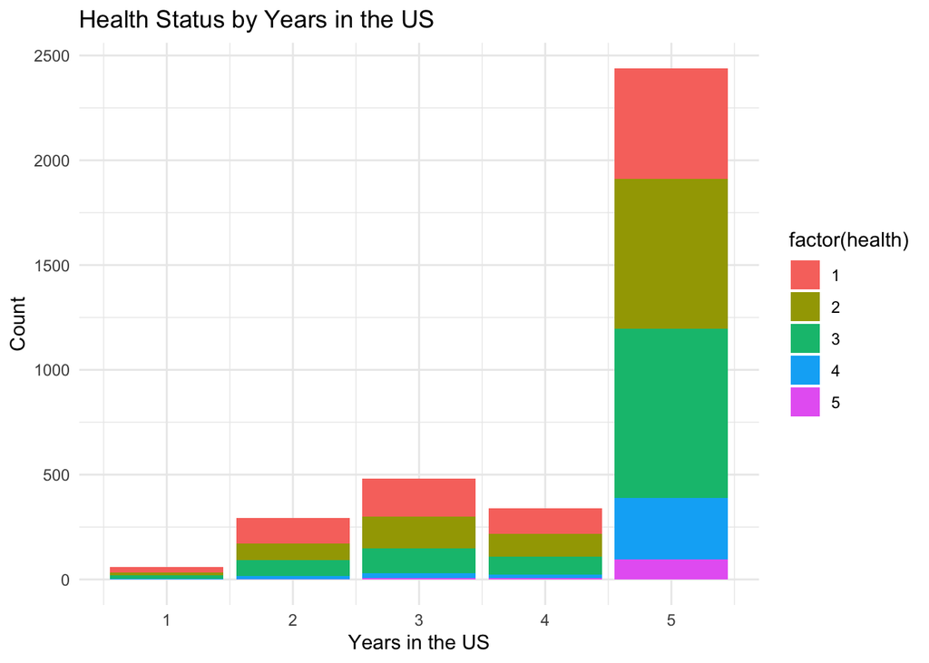

```r
library(ipumsr)
library(tidyverse)
library(tidymodels)
library(ggplot2)
library(corrplot)
library(VGAM)
library(rpart)
library(rpart.plot)
library(hardhat)
library(ranger)

# Loading data

ddi <- read_ipums_ddi("nhis_00001.xml")
data <- read_ipums_micro(ddi)

# Data Cleaning and Subsetting

data_clean <- data %>%
  janitor::clean_names() %>%
  mutate(usborn_binary = if_else(usborn %in% c(10, 11, 12), "1", "2")) %>%
  filter(!(health %in% c(7, 8, 9)), !(yrsinusg %in% c(0, 7, 8, 9))) %>%
  select(!cpi2009 & !year)


data_clean$health <- factor(data_clean$health, levels = 1:5)


# Splitting data into training and testing data

split <- initial_split(data = data_clean, prop = 0.8)

data_train <- training(x = split)
data_test <- testing(x = split)

# Exploratory Data Analysis and Data Cleaning

data_train %>%
  filter(usborn_binary == "1") %>%
  group_by(health, yrsinusg) %>%
  summarise(count = n()) %>%
  ggplot() +
  geom_col(mapping = aes(x = yrsinusg, y = count, fill = factor(health))) +
  labs(title = "Health Status by Years in the US",
       x = "Years in the US",
       y = "Count") +
  theme_minimal()
```

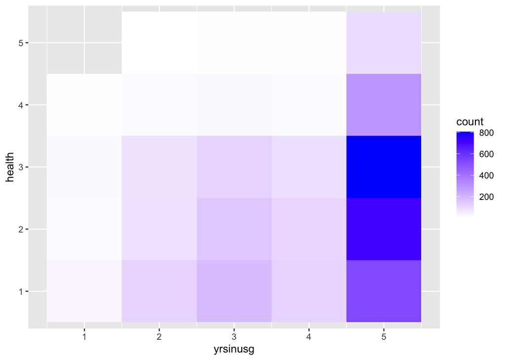

```r
data_train %>%
  filter(usborn_binary == "1") %>%
  group_by(health, yrsinusg) %>%
  summarise(count = n()) %>%
  ggplot(mapping = aes(x = yrsinusg, y = health, fill = count)) +
  geom_tile() +
  scale_fill_gradient(low = "white", high = "blue")
```

I will use accuracy, as my models will be using the classification metric. The cost of an error would be falsely predicting one’s health status. Predicting a health status too high could indicate a inaccurately healthier population, and vice versa for predicting too low. Both errors can have implications on policy interventions. However, the difference in predicting between a 2 or a 3, for example, will have less implications and less of a cost for the model.

2. Come up with Models

Model Specification 1

*Predicting health status* *using demographic variables (ethnicity, race, age, citizenship status, etc.) in a decision tree model.*

```r
# Set up v-fold cross-validation with 10 folds.

folds <- vfold_cv(data = data_train, v = 10)

# Create a recipe

recipe <-
  recipe(health ~ age + sex + hisprace + yrsinusg + citizen, data = data_train) %>%
  step_dummy(all_nominal(), -all_outcomes()) %>%
  step_scale(all_predictors()) %>%
  step_normalize(all_predictors()) %>%
  step_zv(all_predictors()) %>%
  step_center(all_predictors())

bake(prep(recipe, training = data_train), new_data = data_train)
```

```
# A tibble: 3,614 × 6
        age    sex hisprace yrsinusg citizen health
      <dbl>  <dbl>    <dbl>    <dbl>   <dbl> <fct>
 1  0.719   -1.11     1.18     0.619   0.610 3
 2 -0.00127  0.904    1.18     0.619   0.610 3
 3 -0.361   -1.11    -0.974    0.619  -0.961 2
 4 -0.271   -1.11     0.463   -1.22   -0.961 2
 5  0.539    0.904    1.18     0.619   0.610 1
 6  0.0287   0.904    1.18     0.619   0.610 3
 7 -0.782   -1.11    -0.974    0.619   0.610 2
 8 -0.211   -1.11    -0.255    0.619   0.610 1
 9  0.269   -1.11    -0.974    0.619  -0.961 2
10 -0.421    0.904    0.463   -1.22   -0.961 1
# ℹ 3,604 more rows
```

```r
# model specification 1

decision_tree_mod <- decision_tree() %>%
  set_engine(engine = "rpart") %>%
  set_mode(mode = "classification")

# model workflow 1

decision_tree_wf <- workflow() %>%
  add_recipe(recipe) %>%
  add_model(decision_tree_mod)
```

Model Specification 2

*Predicting health status* *using demographic variables (ethnicity, race, age, citizenship status, etc.) in a decision tree model in a KNN model.*

```r
# model specification 2

knn_mod <-
  nearest_neighbor(neighbors = tune()) %>%
  set_engine(engine = "kknn") %>%
  set_mode(mode = "classification")

knn_grid <- grid_regular(neighbors(range = c(1, 49)), levels = 8)

# model workflow 2

knn_wf <- workflow() %>%
  add_recipe(recipe) %>%
  add_model(knn_mod)
```

Model Specification 3

*Predicting health status* *using demographic variables (ethnicity, race, age, citizenship status, etc.) in a Random Forest model.*

```r
# model specification 3

rf_mod <- rand_forest(
  trees = 50,
  min_n = 5) %>%
  set_mode("classification") %>%
  set_engine("ranger")

# create a workflow 3

rf_wf <- workflow() %>%
  add_recipe(recipe) %>%
  add_model(rf_mod)
```

3. Estimation

```r
# fitting random forest model to training data

rf_fit <- fit_resamples(
  rf_wf,
  resamples = folds,
  control = control_resamples(save_pred = TRUE),
  metrics = metric_set(accuracy))

# extract metrics to interpret

metrics <- rf_fit %>%
  collect_metrics(summarize = TRUE)

print(metrics)
```

```
# A tibble: 1 × 6
  .metric  .estimator  mean     n std_err .config
  <chr>    <chr>      <dbl> <int>   <dbl> <chr>
1 accuracy multiclass 0.362    10 0.00378 Preprocessor1_Model1
```

4. Interpretation

One feature engineering choice I may try next to improve upon the result are creating interaction terms. It is clear that several of the variables interact, like citizenship status and years in the US. The more time someone spends in the US, the more likely they are to be a citizen. I may try to create an interaction term to combine the effects of these two variables into one to account for that combined effect. Additionally, another feature engineering tactic I would use is Synthetic Minority Over-sampling Technique (SMOTE). Not all categories of health status have equal frequency in the data set, as evidenced through the data visualizations I created during my exploratory data analysis. By using SMOTE, I could balance the classes.

In terms of modeling choices, I may try to utilize ordinal regression methods instead of classification, which may help improve accuracy of the predictions. Additionally, I will attempt to use a decision tree or KNN which may prove more accurate.